# Population, Temperature, Time

slgately

2026-10-08

**Data Selection and Sampling:**

This analysis uses the NASA ORNL DAYMET V4 dataset, which is a gridded daily weather dataset created by Oak Ridge Laboratory and NASA. This data is collected using ground-based weather stations around North America, using interpolation techniques to estimate weather conditions across the continent. While this analysis only uses the temperature maximum (TMAX) for each day, it also contains the temperature minimum (TMIN), precipitation, shortwave radiation flux, partial pressure of water vapor, and other variables. I am using temperature maximum as the response variable.

I selected the highest temperature of the first day of every month since January 1st, 1980. This is because the analysis is focused on the extremity of high temperatures, not necessarily on an increase in average temperatures. The main question it aims to answer is whether the increase in Phoenix’s population has indirectly affected the intensity of hot temperatures.

The reason I chose Phoenix’s population as a predictor variable is because, as the population grows, more of the surrounding desert area is replaced with heat-absorbing buildings, roads, and houses. Vegetation lowers ambient air temperatures by as much as 9 degrees Fahrenheit (“Using Trees and Vegetation to Reduce Heat Islands”, US Environmental Protection Agency)– meaning that the percentage of an area covered in vegetation can be a predictor for the temperature of that area. As it is difficult to find exact, year-by-year data on the percentage of the Phoenix Metro Area that is covered with concrete, using population, which is measured yearly with the census, is appropriate for a general idea on if, and how, population affects local high temperatures.

**Exploratory Data Analysis:**

The first step in determining whether there is any relationship at all between the Phoenix Metro Area’s (PMA) population growth and increases in air temperature in the region is to establish whether the extremity of high temperatures has actually increased.

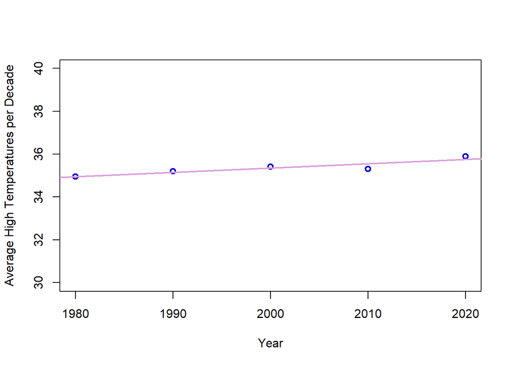

```r
decade_avg$decade_c <- decade_avg$decade - 1980
model <- lm(tmp ~ decade_c, data = decade_avg)

intcpt <- coef(model)[1]
slope <- coef(model)[2]

slope
```

```
##   decade_c
## 0.01993997
```

```r
intcpt
```

```
## (Intercept)
##    34.95055
```

```r
cat(sprintf("y = %fx + %f\n", slope, intcpt))
```

```
## y = 0.019940x + 34.950553
```

In the plot above, the average high temperatures seem to increase linearly as time goes on. In fact, the average high temperature in the PMA has increased by about 0.2 degrees Celsius per decade, or about 0.36 degrees Fahrenheit.

However, as the highest and lowest recorded highs can serve as outliers, skewing the raw average. To find out whether this may be the case, one may start by seeing whether the differences between high and low temperatures has changed significantly, as this could point to a change in seasonal variation rather than a strict increase.

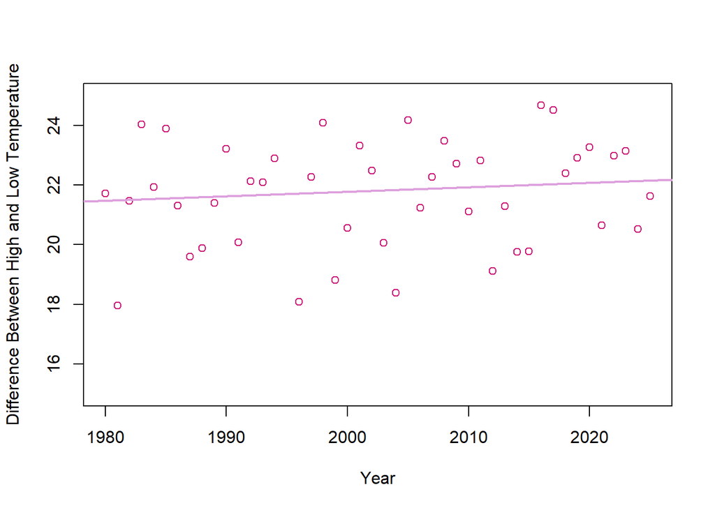

```r
yearly_diff <- aggregate(tmp ~ yy,  data = df, function(x) diff(range(x)))

plot(x = yearly_diff$yy,
        y = yearly_diff$tmp,
        xlab = "Year",
        ylab = "Difference Between High and Low Temperature",
        ylim = c(15,25),
        col = "deeppink3")

yd_mod <- lm(yearly_diff$tmp ~ yearly_diff$yy)
abline(yd_mod, col = "plum", lwd = 2)
```

When electing the metric by which to measure the increase in temperatures as they may be relevant to Phoenix locals, it is important to also consider the frequency with which unusually warm days occur, and the intensity of heat they bring. Such days can scew the measurements of average high temperatures, painting a more extreme picture of the local climate than is experienced in reality.

When removing all datapoints outside of two standard deviations from the norm, the following graph results:

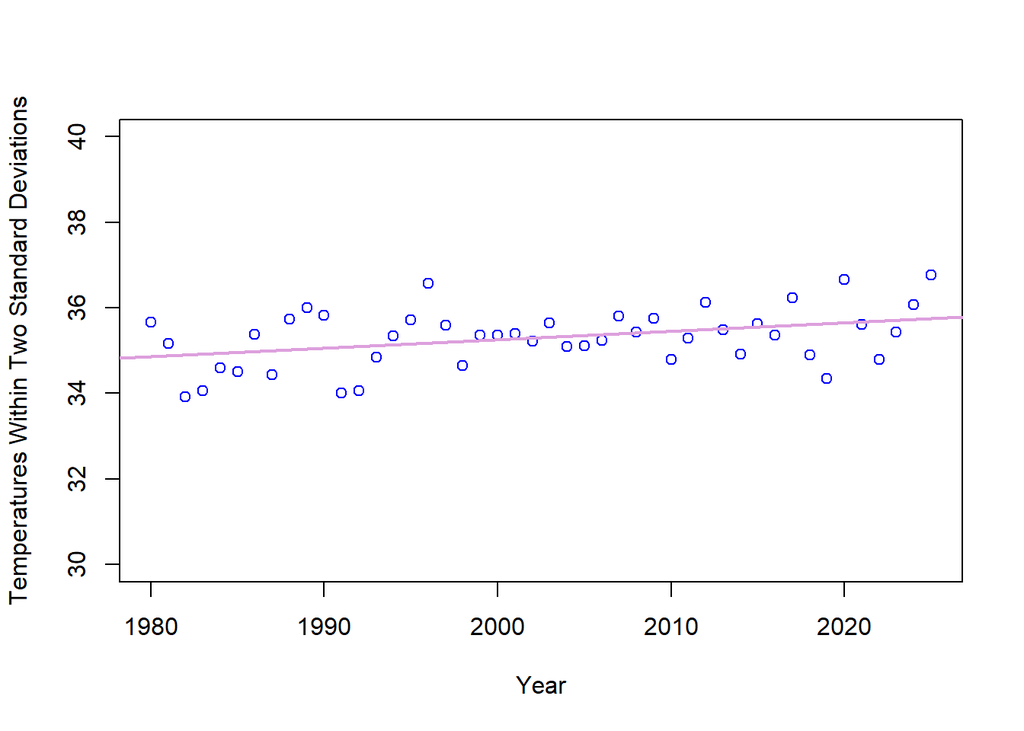

```r
plot(x = no_outs$yy,
     y = no_outs$tmp,
     xlab = "Year",
     ylab = "Temperatures Within Two Standard Deviations",
     ylim = c(30,40),
     col = "blue")

nooutslm <- lm(no_outs$tmp ~ no_outs$yy)
abline(nooutslm, col = "plum", lwd = 2)
```

```r
no_outs$year_c <- no_outs$yy - 1980
model <- lm(tmp ~ year_c, data = no_outs)

intcpt <- coef(model)[1]
slope <- coef(model)[2]

slope
```

```
##     year_c
## 0.01973271
```

```r
intcpt
```

```
## (Intercept)
##     34.8585
```

```r
cat(sprintf("y = %fx + %f\n", slope, intcpt))
```

```
## y = 0.019733x + 34.858496
```

The final result still shows an increase of about 0.02 degrees per year, even with the most extreme datapoints removed.

**On Population**

I had a similar curiosity about whether the noticeable increase in PMA population showed a correlation with higher temperatures. Like the exploration of the temperature data, the first step in investigating this trend is to establish whether an increase is supported by the data.

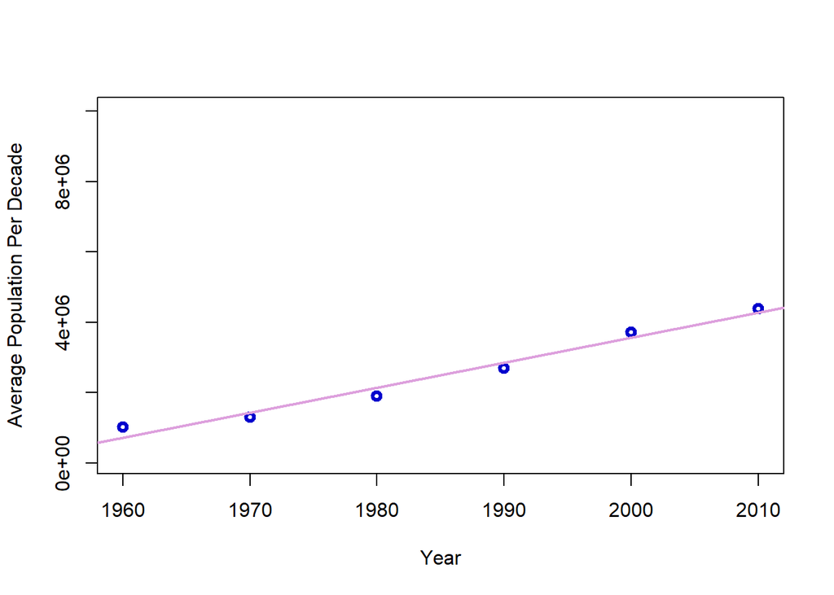

```r
decade_pop_avg <- aggregate(population ~ decade,  data = new_df_pop, FUN = mean, na.rm = TRUE)
plot(x = decade_pop_avg$decade,
     y = decade_pop_avg$population,
     xlab = "Year",
     ylab = "Average Population Per Decade",
     ylim = c(100000,10000000),
     lwd = 3,
     col = "blue3")
abline(lm(decade_pop_avg$population ~ decade_pop_avg$decade), col = "plum", lwd = 2)
```

```r
decade_pop_avg$decade_c <- decade_pop_avg$decade - 1980
model <- lm(population ~ decade_c, data = decade_pop_avg)

intcpt <- coef(model)[1]
slope <- coef(model)[2]

slope
```

```
## decade_c
## 71075.08
```

```r
intcpt
```

```
## (Intercept)
##     2145093
```

```r
cat(sprintf("y = %fx + %f\n", slope, intcpt))
```

```
## y = 71075.080476x + 2145092.503175
```

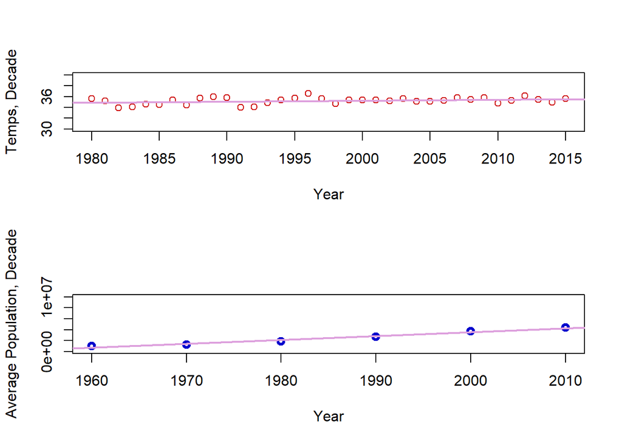

```r
par(mfrow = c(2,1))
scale_tmp <- subset(no_outs, yy >= 1980 & yy<= 2015)
no_outs2 <- aggregate(tmp ~ yy, data = scale_tmp, FUN = mean, na.rm = TRUE)

par(mfrow = c(2,1))
plot(x = no_outs2$yy,
     y = no_outs2$tmp,
     xlab = "Year",
     ylab = "Temps, Decade",
     ylim = c(30,40),
     col = "red3")

nooutslm <- lm(no_outs$tmp ~ no_outs$yy)
abline(nooutslm, col = "plum", lwd = 2)

#population scaled to 1980 - present
plot(x = decade_pop_avg$decade,
     y = decade_pop_avg$population,
     xlab = "Year",
     ylab = "Average Population, Decade",
     ylim = c(100000,10000000),
     lwd = 3,
     col = "blue3")
abline(lm(decade_pop_avg$population ~ decade_pop_avg$decade), col = "plum", lwd = 2)
```

```r
no_outs2$decade_c <- no_outs2$yy - 1980;
model <- lm(tmp ~ decade_c, data = no_outs2);

intcpt <- coef(model)[1];
slope <- coef(model)[2];

slope
```

```
##   decade_c
## 0.02077072
```

```r
intcpt
```

```
## (Intercept)
##    34.85196
```

```r
cat(sprintf("y = %fx + %f\n", slope, intcpt))
```

```
## y = 0.020771x + 34.851961
```

```r
decade_pop_avg$decade_c <- decade_pop_avg$decade - 1980
model <- lm(population ~ decade_c, data = decade_pop_avg)

intcpt <- coef(model)[1]
slope <- coef(model)[2]

slope
```

```
## decade_c
## 71075.08
```

```r
intcpt
```

```
## (Intercept)
##     2145093
```

```r
cat(sprintf("y = %fx + %f\n", slope, intcpt))
```

```
## y = 71075.080476x + 2145092.503175
```

**Limitations and Reasoning**

Firstly, the temperature is measured by highs, not by the average overall daily temperature, or by the lows. This is intentional, serving to highlight one of the most dangerous features of Arizona’s climate: extreme heat. I wanted to focus mainly on extreme heat due to the fatal risk is poses to the state’s most vulnerable populations: disabled people, the unhoused population, the elderly, and those who cannot afford air conditioning (“Understanding the Heat Island Index”, California Environmental Protection Agency). This project establishes a case for these fatal temperatures becoming more intense, but it cannot and does not claim to be a model of Arizona’s climate overall.

Lastly, the connection to population growth is left as a correlation. Population growth is used by the analysis as a proxy for increased urbanization- the construction of new roads, buildings, and concrete spaces- which itself is not easily measured. The destruction of local ecosystems to make way for construction has lead to the creation of heat islands. However, two things are true: I did not measure increased high temperatures against urbanization rates, and I did not create a linear regression model to measure population growth against the temperature measurements. As such, the results of this study are enough for me to hypothesize that population may play an indirect role in more extreme high temperatures, but are certainly not conclusive.